# TP2 - Econometrics

# Importing libraries :

```r
library(stats)
library(forecast)
library(ggplot2)
```

# Part 1 : Additional processes

## Exercise 2 : Explosive process

### 1. Simulate an explosive ARMA(p,q) process. You are free to select numbers for p and q.

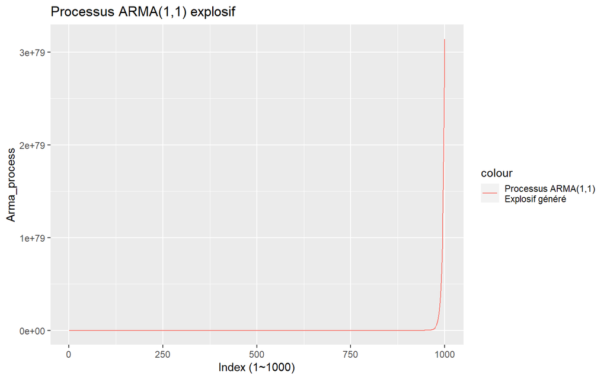

```r
set.seed(123)
#Generating a Gaussian white noises process :
wn <- rnorm(1000,0,1)
#Generating the ARMA(p,q) process :
#Un processus explosif est un processus possédant au moins une racine autoregressive hors du cercle unité
arma_process <- wn[1:2]
for (t in 3:1000){
  arma_process[t] = 1.2*arma_process[t-1] + wn[t] + 0.8*wn[t-1]
}

# Représentation graphique du résultat :
df <- data.frame(x = 1:1000, y = arma_process)
arma_plot <- ggplot(df, aes(x = df$x, y = df$y, col = "Processus ARMA(1,1)\nExplosif généré")) + geom_line() + ggtitle("Processus ARMA(1,1) explosif") + xlab("Index (1~1000)") + ylab("Arma_process")
arma_plot
```

> On observe déjà graphiquement un premier résultat pour la question 2 étant l’abscence de stationnarité due à la divergence à partir d’un certain rang. Cette explosion est due au fait que la racine du polynome de la partie AR du processus est située à l’intérieur du cercle unitaire (On le verifiera par la suite).

### 2. Verify your ARMA(p,q) process does not respect the required conditions to be stationary. Use all the tools you know to reply to this question.

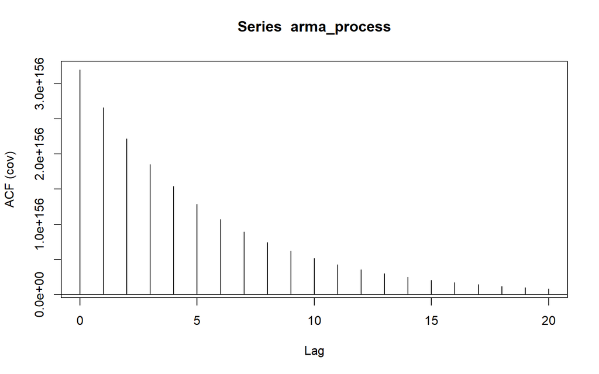

```r
autocovariance_arma <- acf(arma_process, lag = 20, type = "covariance")
```

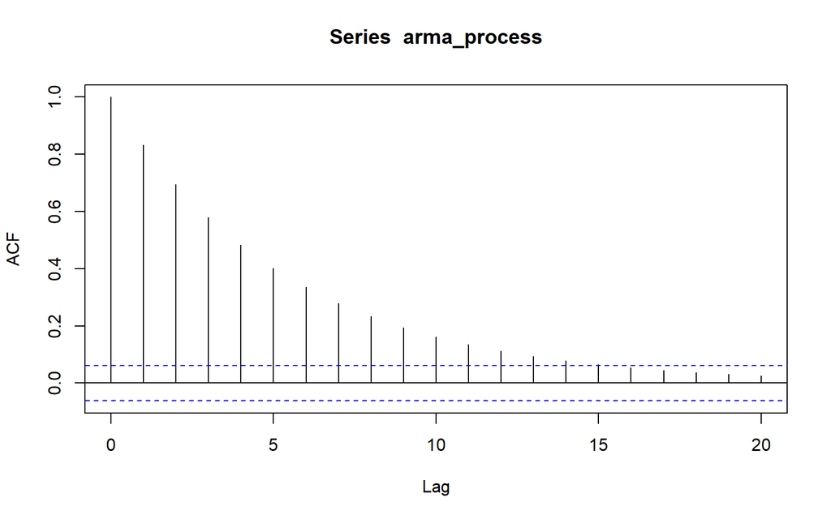

```r
autocorrelation_arma <- acf(arma_process, lag = 20, type = "correlation")
```

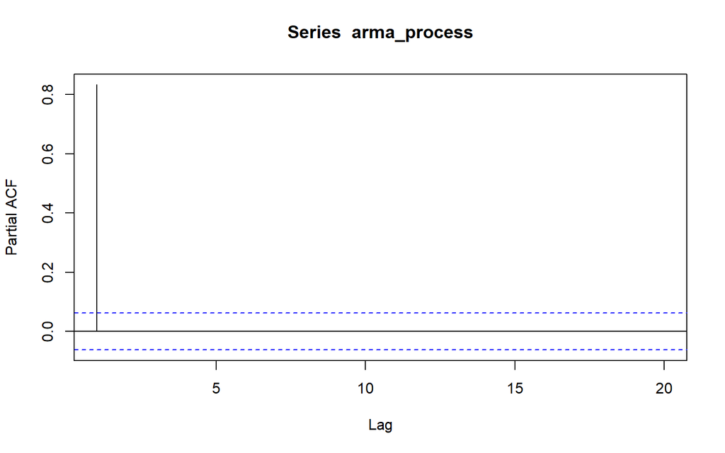

```r
pacf_arma <- pacf(arma_process, lag = 20)
```

```r
#Circle <- arima(arma_process, order = c(1,0,1))
#plot(Circle)
```

On peut néanmoins procéder autrement pour représenter le cercle unitaire et les racines du polynôme caractéristique AR :

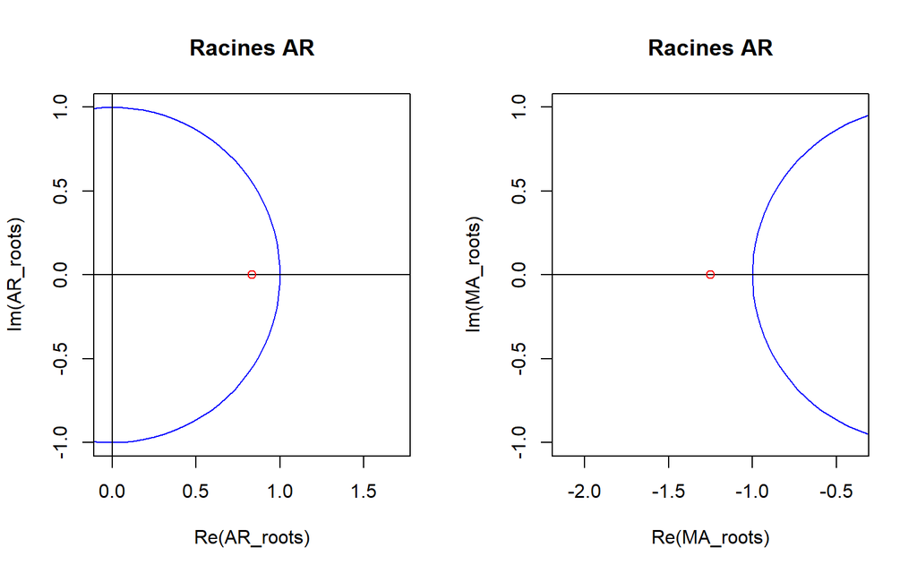

```r
coeff_AR <- c(1,-1.2) # Coefficients du polynôme caractéristique AR
coeff_MA <- c(1,0.8) # Coefficients du polynôme caractéristique MA
AR_roots <- polyroot(coeff_AR)
MA_roots <- polyroot(coeff_MA)

AR_roots <- matrix(c(AR_roots))
MA_roots <- matrix(c(MA_roots))

par(mfrow = c(1,2))
plot(
  AR_roots,
  ylim=c(-1, 1),
  col = "red",
  asp=1,
  main="Racines AR",
  panel.first=c(
    lines(complex(modulus=1, argument=0.01*2*pi)^(0:100), col='blue'),
    abline(h=0, col='black'),
    abline(v=0, col='black')
  )
)

plot(
  MA_roots,
  ylim=c(-1, 1),
  col = "red",
  asp=1,
  main="Racines AR",
  panel.first=c(
    lines(complex(modulus=1, argument=0.01*2*pi)^(0:100), col='blue'),
    abline(h=0, col='black'),
    abline(v=0, col='black')
  )
)
```

> Comme prévu, la racine du polynôme caractéristique AR est située à l’interieur du cercle unitaire. Ainsi, il y’a abscence de stationnarité.

### 3. Make a forecast over 12 periods ahead and plot the interval confidences. What do you observe. Is it aligned with the theory ?

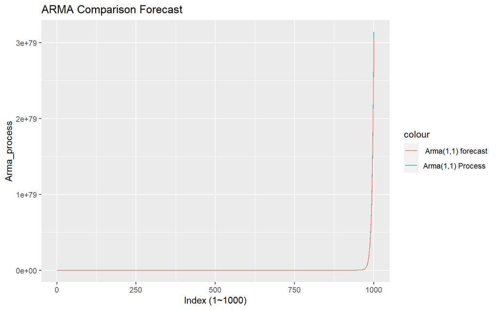

```r
fc <- forecast(arma_process, level = c(0.95), h = 12)
ggplot(df, aes(x = df$x, y = df$y, col = "Arma(1,1) Process")) + geom_line() + geom_line(aes(y= fc$fitted, col = " Arma(1,1) forecast")) + ggtitle("ARMA Comparison Forecast") + xlab("Index (1~1000)")+ylab("Arma_process")
```

```r
#plot(fc$level, col = "Blue", main = "Confidence Interval")
```

> On observe une superposition des deux graphiques, ainsi le resultat est aligné avec la théorie.

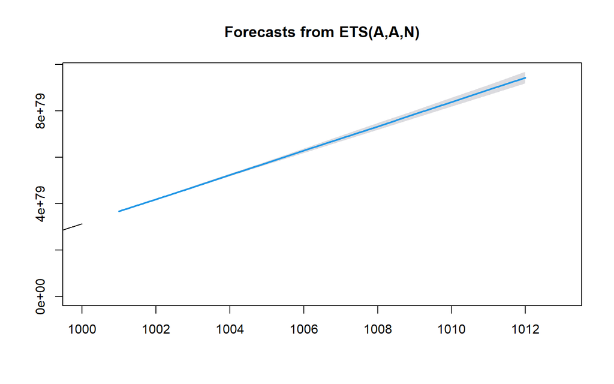

```r
plot(fc, xlim=c(1000,1013))
```

> On observe enfin que la représentation graphique est comprise dans l’intervalle de confiance

#Part 2 : Moving to real data

We continue the study of ARMA models using the US Producer Price Index (excluding fresh food and energy). The data are available since 1974 until now. Can the ARMA framework help us to model the dynamics of this key variable and anticipate its behavior ?

### 1. Load the PPI data from your workspace. Convert and plot the time series. Can the producer prices index be modeled without any transformation ? Explain.

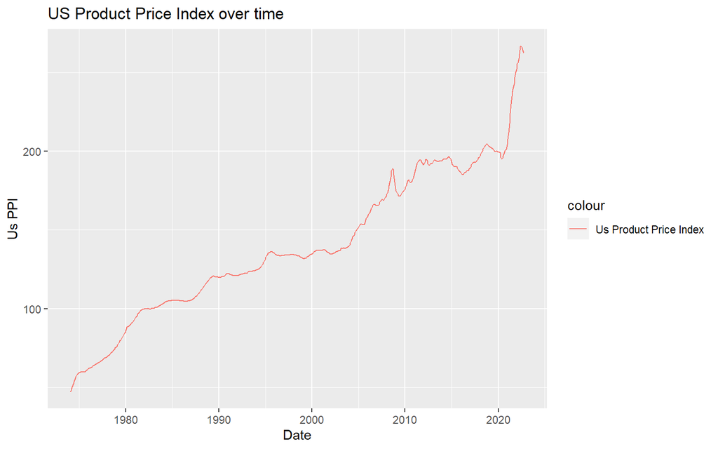

```r
PPI <- read.csv("usppi.csv" ,header = TRUE, sep = ",")
PPI$Date <- as.Date(PPI$Date, format = "%m/%d/%Y")

ggplot(PPI,aes(x = PPI$Date, y = PPI$usppi, col = "Us Product Price Index")) + geom_line() + xlab("Date") + ylab("Us PPI") + ggtitle("US Product Price Index over time")
```

> On constate une croissance du prix de produit au cours du temps. Concernant la modélisation, elle n’est pas possible sans conversion car les objets initiaux dans le Dataframe ne sont pas de type date donc les valeurs ne sont pas reconnues et ne peuvent donc pas être utilisées pour le graphique.

On peut également convertir le dataset en série temporelle :

```r
PPI.ts=ts(data=PPI$usppi, start=c(1974,1, 15), end=c(2022, 10, 15), frequency = 12)
head(PPI.ts, n = 24)
```

```
##       Jan  Feb  Mar  Apr  May  Jun  Jul  Aug  Sep  Oct  Nov  Dec
## 1974 47.5 48.1 49.5 50.9 52.5 53.7 55.2 57.0 57.6 58.2 58.8 59.1
## 1975 59.6 59.8 59.7 59.7 59.7 59.8 59.9 60.1 60.3 61.0 61.4 61.8
```

### 2. Calculate the monthly growth rate of the PPI between January 1981 and December 2021. Can the PPI inflation be modeled now with an ARMA(p,q) ?

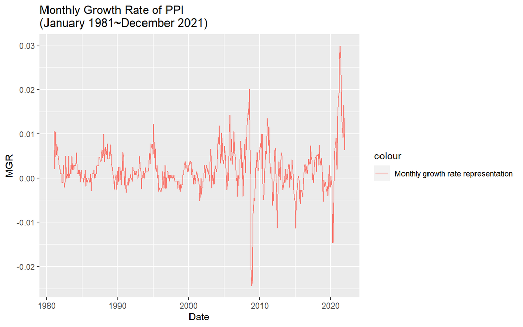

```r
Monthly_gr <- data.frame(Date = PPI$Date[85:576], MGR = 0*PPI$usppi[85:576])
for (i in 85:576){
  Monthly_gr$MGR[i-84] <- (PPI$usppi[i] - PPI$usppi[i-1])/PPI$usppi[i-1]
}

MGR_plot <- ggplot(Monthly_gr, aes(x = Monthly_gr$Date, y = Monthly_gr$MGR, col = "Monthly growth rate representation"))  + geom_line() + xlab("Date") + ylab("MGR") + ggtitle("Monthly Growth Rate of PPI\n(January 1981~December 2021)")
MGR_plot
```

> On observe une allure stationnaire sur le graphique, il est alors possible de considérer le modèle ARMA(p,q) pour faire des prédictions.

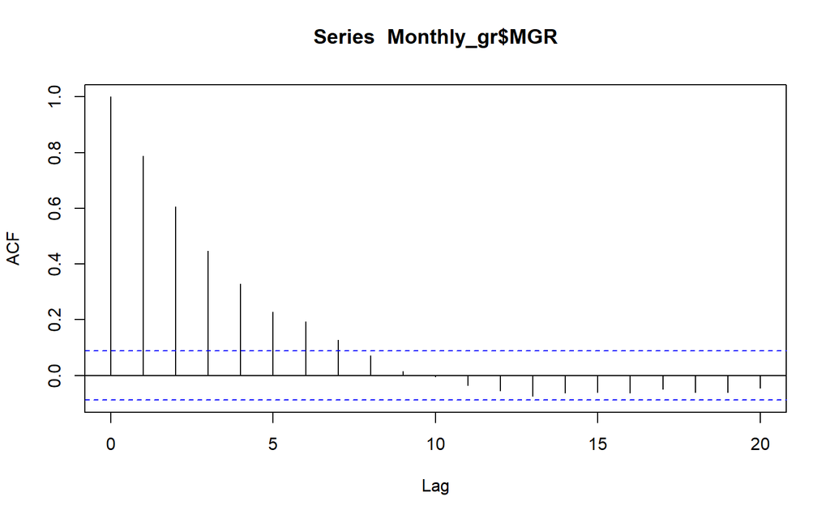

```r
autocorrelation_MGR <- acf(Monthly_gr$MGR, lag = 20, type = "correlation")
```

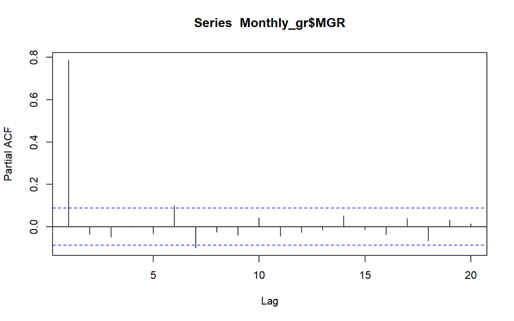

```r
pacf_MGR <- pacf(Monthly_gr$MGR, lag = 20)
```

```r
autocorrelation_MGR
```

```
##
## Autocorrelations of series 'Monthly_gr$MGR', by lag
##
##      0      1      2      3      4      5      6      7      8      9     10
##  1.000  0.787  0.606  0.447  0.328  0.227  0.193  0.127  0.072  0.015 -0.004
##     11     12     13     14     15     16     17     18     19     20
## -0.036 -0.056 -0.075 -0.062 -0.061 -0.062 -0.049 -0.060 -0.060 -0.045
```

```r
pacf_MGR
```

```
##
## Partial autocorrelations of series 'Monthly_gr$MGR', by lag
##
##      1      2      3      4      5      6      7      8      9     10     11
##  0.787 -0.037 -0.050  0.002 -0.032  0.100 -0.101 -0.025 -0.041  0.041 -0.045
##     12     13     14     15     16     17     18     19     20
## -0.028 -0.017  0.052 -0.014 -0.038  0.038 -0.067  0.031  0.013
```

> Comme on considère un modèle ARMA, la partie autoregressif fait que l’on ne peut pas déterminer l’ordre du modèle sur le diagramme d’autocorrélations. On représente alors la PACF et on observe un pic significatif d’ordre 1 pour la partie autoregréssive.Pour la partie MA en revanche, on observe un dernier pic significatif à l’indice 7 sur le diagramme d’autocorrélations. Ainsi le modèle considéré est un ARMA(1,7)